# Intuit Quickbooks Upgrade

- Team-lead GitLab userid: sguniset
- Group name: Avengers
- Team member names: Ines - Mouli - Srikar - Xuefei

## Setup

Please complete this python notebook with your group by answering the questions in `intuit-redux.pdf`. Create a Notebook and HTML file with all your results and comments and push both the Notebook and HTML file to GitLab when your team is done. All results MUST be reproducible (i.e., the TA and I must be able to recreate the HTML file from the Jupyter Notebook without changes or errors). This means that you should NOT use any python-packages that are not part of the rsm-msba-spark docker container.

This is the second group assignment for MGTA 455 and you will be using Git and GitLab. If two people edit the same file at the same time you could get what is called a "merge conflict". This is not something serious but you should realize that Git will not decide for you who's change to accept so the team-lead will have to determine the edits to use. To avoid merge conflicts, **always** "pull" changes from the repo before you start working on any files. Then, when you are done, save and commit your changes, and then push them to GitLab. Make "pull first" a habit!

A graphical depiction of the group work-flow is shown below:

[figure not shown]

Tutorial videos about using Git, GitLab, and GitGadget for group assignments:

- Setup the MSBA server to use Git and GitLab: https://youtu.be/zJHwodmjatY
- Dealing with Merge Conflicts: https://youtu.be/qFnyb8_rgTI
- Group assignment practice: https://youtu.be/4Ty_94gIWeA

```python
#libraries

import numpy as np
import pandas as pd
import pyrsm as rsm
from math import sqrt

import matplotlib as mpl
import matplotlib.pyplot as plt
import seaborn as sns

import statsmodels.formula.api as smf
from statsmodels.genmod.families import Binomial
from statsmodels.genmod.families.links import logit

from sklearn import preprocessing
from sklearn.inspection import permutation_importance
from sklearn.model_selection import GridSearchCV, train_test_split
from sklearn.neural_network import MLPClassifier
from sklearn.linear_model import LogisticRegression


from sklearn.ensemble import RandomForestClassifier
from sklearn.ensemble import AdaBoostClassifier
from sklearn.ensemble import VotingClassifier
from sklearn.tree import DecisionTreeClassifier


import xgboost as xgb

from sklearn import metrics

sns.set_theme(style="darkgrid", palette="muted")

# increase plot resolution
mpl.rcParams["figure.dpi"] = 100

import warnings
warnings.simplefilter(action="ignore", category=FutureWarning)
```

```python
## loading the data - this dataset must NOT be changed

intuit75k = pd.read_pickle("data/intuit75k.pkl")

#OHE - Buyer variables & Zip Bins variable
intuit75k["res1_yes"] = (intuit75k["res1"] == "Yes").astype(int)
intuit75k["is_zip801"] = (intuit75k["zip"] == "00801").astype(int)
intuit75k["is_zip804"] = (intuit75k["zip"] == "00804").astype(int)

intuit75k.head()
```

|  | id | zip | zip_bins | sex | bizflag | numords | dollars | last | sincepurch | version1 | owntaxprod | upgraded | res1 | training | res1_yes | is_zip801 | is_zip804 |
| --- | --- | --- | --- | --- | --- | --- | --- | --- | --- | --- | --- | --- | --- | --- | --- | --- | --- |
| 0 | 1 | 94553 | 18 | Male | 0 | 2 | 109.5 | 5 | 12 | 0 | 0 | 0 | No | 1 | 0 | 0 | 0 |
| 1 | 2 | 53190 | 10 | Unknown | 0 | 1 | 69.5 | 4 | 3 | 0 | 0 | 0 | No | 0 | 0 | 0 | 0 |
| 2 | 3 | 37091 | 8 | Male | 0 | 4 | 93.0 | 14 | 29 | 0 | 0 | 1 | No | 0 | 0 | 0 | 0 |
| 3 | 4 | 02125 | 1 | Male | 0 | 1 | 22.0 | 17 | 1 | 0 | 0 | 0 | No | 1 | 0 | 0 | 0 |
| 4 | 5 | 60201 | 11 | Male | 0 | 1 | 24.5 | 2 | 3 | 0 | 0 | 0 | No | 0 | 0 | 0 | 0 |

```python
# show dataset description
rsm.describe(intuit75k)
```

Intuit: Quickbooks upgrade

The purpose of this exercise is to gain experience modeling the response to an upsell campaign. The `intuit75k.rds` file contains data on 75,000 (small) businesses that were selected randomly from the 801,821 that were sent the wave-1 mailing. The mailing contained an offer to upgrade to the latest version of the Quickbooks software.

Variable `res1` denotes which of these businesses responded to the mailing by purchasing Quickbooks version 3.0 from Intuit Direct. Note that Intuit Direct sells products directly to its customers rather than through a retailer. Use the available data to predict which businesses that did not respond to the wave-1 mailing, are most likely to respond to the wave-2 mailing. Note that variables were added, deleted, and recoded so please ignore the variable descriptions in Exhibit 3 in the case in the course reader. Instead, use the variable descriptions below:

Variable description

- id: Small business customer ID

- zip: 5-Digit ZIP Code (00000=unknown, 99999=international ZIPs).

- zip_bins: Zip-code bins (20 approx. equal sized bins from lowest to highest zip code number)

- sex: "Female", "Male", or "Unknown"

- bizflag: Business Flag. Address contains a Business name (1 = yes, 0 = no or unknown).

- numords: Number of orders from Intuit Direct in the previous 36 months

- dollars: Total $ ordered from Intuit Direct in the previous 36 months

- last: Time (in months) since last order from Intuit Direct in previous 36 months

- sincepurch: Time (in months) since original (not upgrade) purchase of Quickbooks

- version1: Is 1 if customer's current Quickbooks is version 1, 0 if version 2

- owntaxprod: Is 1 if customer purchased tax software, 0 otherwise

- upgraded: Is 1 if customer upgraded from Quickbooks vs. 1 to vs. 2

- res1: Response to wave 1 mailing ("Yes" if responded else "No")

- training: 70/30 split, 1 for training sample, 0 for validation sample

```python
# which column to standardize (i.e., numeric variables)
to_std = intuit75k.loc[:,'numords':'sincepurch'].columns

#List of variables to standardize
to_std
```

```
Index(['numords', 'dollars', 'last', 'sincepurch'], dtype='object')
```

```python
#make a copy of the main dataframe
intuit75k_std         = intuit75k.copy()

# scale numeric variables by (x - mean(x)) / sd(x)
intuit75k_std[to_std] = rsm.scale_df(intuit75k_std[to_std], sf=2, train = intuit75k_std.training == 1)
intuit75k_std['zip_bins'] = intuit75k_std['zip_bins'].astype(str)
#verify standardization
intuit75k_std.loc[intuit75k_std.training == 1, to_std].agg([np.mean, np.std]).round(2)
```

|  | numords | dollars | last | sincepurch |
| --- | --- | --- | --- | --- |
| mean | 0.0 | -0.0 | -0.0 | 0.0 |
| std | 0.5 | 0.5 | 0.5 | 0.5 |

```python
intuit75k_std.head()
```

|  | id | zip | zip_bins | sex | bizflag | numords | dollars | last | sincepurch | version1 | owntaxprod | upgraded | res1 | training | res1_yes | is_zip801 | is_zip804 |
| --- | --- | --- | --- | --- | --- | --- | --- | --- | --- | --- | --- | --- | --- | --- | --- | --- | --- |
| 0 | 1 | 94553 | 18 | Male | 0 | -0.028540 | 0.103951 | -0.568592 | -0.180404 | 0 | 0 | 0 | No | 1 | 0 | 0 | 0 |
| 1 | 2 | 53190 | 10 | Unknown | 0 | -0.431860 | -0.143280 | -0.620965 | -0.629335 | 0 | 0 | 0 | No | 0 | 0 | 0 | 0 |
| 2 | 3 | 37091 | 8 | Male | 0 | 0.778101 | 0.001968 | -0.097229 | 0.667575 | 0 | 0 | 1 | No | 0 | 0 | 0 | 0 |
| 3 | 4 | 02125 | 1 | Male | 0 | -0.431860 | -0.436868 | 0.059891 | -0.729097 | 0 | 0 | 0 | No | 1 | 0 | 0 | 0 |
| 4 | 5 | 60201 | 11 | Male | 0 | -0.431860 | -0.421416 | -0.725712 | -0.629335 | 0 | 0 | 0 | No | 0 | 0 | 0 | 0 |

```python
# Function to check for overfitting between test and training data using Lift & Gains Plot

def overfitting_check(prediction, df = intuit75k_std, model = None):
    dct_nn = {"Training":df.query("training == 1"), "Test":df.query("training == 0")}
    plt.figure(figsize = (14,6))
    plt.suptitle("Gains & Lift Plot comparison btw Test & Training data using " + model, fontsize = 12, y = 0.95)
    ax1 = plt.subplot(1, 2, 1)
    rsm.gains_plot(dct_nn, "res1", "Yes", prediction, ax = ax1)
    ax2 = plt.subplot(1, 2, 2)
    rsm.lift_plot(dct_nn, "res1", "Yes", prediction, ax = ax2)
    plt.show()
```

### LOGISTIC REGRESSION

```python
# Logistic Regression Model including interactions between message and other explantory variabls
# Training the model using "TRAINING" data only!!

lr_std = smf.glm(formula = """res1_yes ~ zip_bins + sex + \
                              bizflag + numords + dollars + last + sincepurch + version1 + \
                              owntaxprod + upgraded + is_zip801 + is_zip804 + numords:version1 + last:version1""",
                 family = Binomial(link=logit()),
                 data = intuit75k_std[intuit75k_std.training == 1]
                ).fit()
```

```python
print(lr_std.summary())
```

```
                 Generalized Linear Model Regression Results
==============================================================================
Dep. Variable:               res1_yes   No. Observations:                52500
Model:                            GLM   Df Residuals:                    52466
Model Family:                Binomial   Df Model:                           33
Link Function:                  logit   Scale:                          1.0000
Method:                          IRLS   Log-Likelihood:                -8479.8
Date:                Fri, 04 Mar 2022   Deviance:                       16960.
Time:                        17:43:43   Pearson chi2:                 5.17e+04
No. Iterations:                     7
Covariance Type:            nonrobust
====================================================================================
                       coef    std err          z      P>|z|      [0.025      0.975]
------------------------------------------------------------------------------------
Intercept           -3.9529      0.163    -24.184      0.000      -4.273      -3.633
zip_bins[T.10]       0.0582      0.185      0.314      0.753      -0.305       0.421
zip_bins[T.11]       0.1155      0.184      0.627      0.531      -0.246       0.477
zip_bins[T.12]       0.4085      0.177      2.307      0.021       0.061       0.755
zip_bins[T.13]      -0.0151      0.188     -0.081      0.936      -0.383       0.352
zip_bins[T.14]       0.1217      0.183      0.664      0.507      -0.237       0.481
zip_bins[T.15]       0.0190      0.186      0.102      0.919      -0.346       0.384
zip_bins[T.16]       0.1157      0.183      0.633      0.527      -0.243       0.474
zip_bins[T.17]       0.1124      0.183      0.614      0.539      -0.246       0.471
zip_bins[T.18]       0.4722      0.175      2.695      0.007       0.129       0.816
zip_bins[T.19]       0.2174      0.181      1.201      0.230      -0.138       0.572
zip_bins[T.2]        0.2594      0.181      1.436      0.151      -0.095       0.613
zip_bins[T.20]       0.0830      0.184      0.451      0.652      -0.278       0.444
zip_bins[T.3]        0.0338      0.187      0.181      0.857      -0.333       0.401
zip_bins[T.4]        0.1657      0.182      0.912      0.362      -0.190       0.522
zip_bins[T.5]        0.0146      0.187      0.078      0.938      -0.352       0.381
zip_bins[T.6]        0.0941      0.183      0.514      0.607      -0.265       0.453
zip_bins[T.7]        0.0531      0.185      0.287      0.774      -0.309       0.416
zip_bins[T.8]        0.1112      0.183      0.608      0.543      -0.247       0.470
zip_bins[T.9]        0.0716      0.185      0.388      0.698      -0.290       0.434
sex[T.Male]         -0.0084      0.055     -0.154      0.878      -0.115       0.099
sex[T.Unknown]      -0.0366      0.078     -0.471      0.638      -0.189       0.116
bizflag              0.0464      0.050      0.923      0.356      -0.052       0.145
numords              0.3722      0.056      6.700      0.000       0.263       0.481
dollars              0.1890      0.045      4.208      0.000       0.101       0.277
last                -0.6675      0.055    -12.244      0.000      -0.774      -0.561
sincepurch           0.0436      0.082      0.531      0.595      -0.117       0.205
version1             0.4212      0.097      4.358      0.000       0.232       0.611
owntaxprod           0.4028      0.105      3.849      0.000       0.198       0.608
upgraded             1.0003      0.088     11.371      0.000       0.828       1.173
is_zip801            3.2546      0.164     19.831      0.000       2.933       3.576
is_zip804            2.9124      0.250     11.661      0.000       2.423       3.402
numords:version1     0.8292      0.088      9.442      0.000       0.657       1.001
last:version1       -0.7939      0.112     -7.089      0.000      -1.013      -0.574
====================================================================================
```

```python
print(rsm.model_fit(lr_std))
```

```
Pseudo R-squared (McFadden): 0.156
Pseudo R-squared (McFadden adjusted): 0.153
Area under the RO Curve (AUC): 0.774
Log-likelihood: -8479.762, AIC: 17027.524, BIC: 17329.055
Chi-squared: 51651.091 df(33), p.value < 0.001
Nr obs: 52,500

None
```

```python
intuit75k_std['pred_lr'] = lr_std.predict(intuit75k_std)
intuit75k_std.head()
```

|  | id | zip | zip_bins | sex | bizflag | numords | dollars | last | sincepurch | version1 | owntaxprod | upgraded | res1 | training | res1_yes | is_zip801 | is_zip804 | pred_lr |
| --- | --- | --- | --- | --- | --- | --- | --- | --- | --- | --- | --- | --- | --- | --- | --- | --- | --- | --- |
| 0 | 1 | 94553 | 18 | Male | 0 | -0.028540 | 0.103951 | -0.568592 | -0.180404 | 0 | 0 | 0 | No | 1 | 0 | 0 | 0 | 0.042763 |
| 1 | 2 | 53190 | 10 | Unknown | 0 | -0.431860 | -0.143280 | -0.620965 | -0.629335 | 0 | 0 | 0 | No | 0 | 0 | 0 | 0 | 0.023382 |
| 2 | 3 | 37091 | 8 | Male | 0 | 0.778101 | 0.001968 | -0.097229 | 0.667575 | 0 | 0 | 1 | No | 0 | 0 | 0 | 0 | 0.078289 |
| 3 | 4 | 02125 | 1 | Male | 0 | -0.431860 | -0.436868 | 0.059891 | -0.729097 | 0 | 0 | 0 | No | 1 | 0 | 0 | 0 | 0.013703 |
| 4 | 5 | 60201 | 11 | Male | 0 | -0.431860 | -0.421416 | -0.725712 | -0.629335 | 0 | 0 | 0 | No | 0 | 0 | 0 | 0 | 0.025852 |

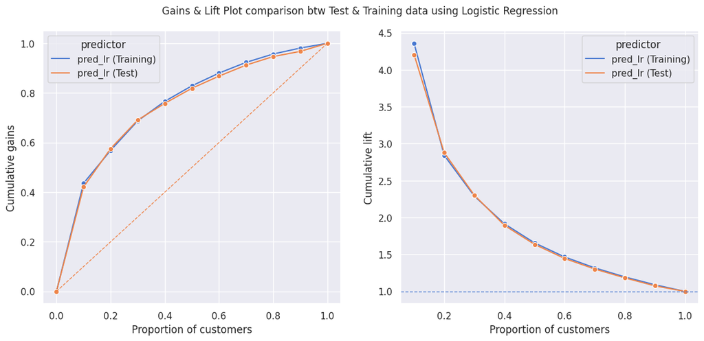

```python
#Check for over-fitting
overfitting_check('pred_lr', intuit75k_std, model = "Logistic Regression")
```